# Спецификация к Лабораторной работе №7

# Упорядочение массива методами простого выбора и «пузырька».

# (Вариант 22)

## Абстракция А0

### 1. Постановка задачи.

#### Задание:

Написать программы упорядочения одномерного массива двумя методами:

- методом простого выбора и
- методом «пузырька».

#### Условие:

Заданный целочисленный массив $\{A_1, A_2, …, A_n\}$ отсортировать в порядке убывания (минимум - в конец).

Порядок элементов выводить на экран после каждого прохода по массиву.

### 2. Уточненная постановка задачи.

Дан одномерный целочисленный массив A из n элементов.

1) Выполнить сортировку методом простого выбора:

на каждом i-ом этапе сортировки поменять местами

- минимальный элемент массива $\{A_1, A_2, …, A_{n - i + 1}\}$ с индексом k и
- элемент с индексом (n - i + 1).

2) Выполнить сортировку методом "пузырька":

- на очередном этапе сравниваются все соседние элементы,
- в каждой паре элементы меняются местами, если первый элемент меньше второго,
- последний элемент полученного массива исключается из анализа на следующем этапе.

### 3. Пример с иллюстрацией.

```python
from IPython.display import Image
import numpy
import pylab
%matplotlib inline
pylab.style.use('seaborn-whitegrid')
```

```python
A1 = numpy.random.randint(-100, 100, size=20)
numpy.savetxt('A_Lab7_1.txt', A1, fmt='%5.0f')
As1 = numpy.sort(A1)[::-1]
str(list(A1)), str(list(As1))
```

```
('[-78, 26, -3, 32, -48, -97, -80, 49, 86, -32, 91, 58, 82, 19, 98, -65, -93, 40, 6, -47]',
 '[98, 91, 86, 82, 58, 49, 40, 32, 26, 19, 6, -3, -32, -47, -48, -65, -78, -80, -93, -97]')
```

```python
A2 = numpy.random.randint(0, 2, size=20)
numpy.savetxt('A_Lab7_2.txt', A2, fmt='%5.0f')
As2 = numpy.sort(A2)[::-1]
print('\n', A2, '\n', As2)
```

```
 [1 1 0 0 0 0 0 1 1 1 1 1 1 0 0 1 0 0 1 0]
 [1 1 1 1 1 1 1 1 1 1 0 0 0 0 0 0 0 0 0 0]
```

```python
A3 = numpy.random.randint(1, 10, size=5)
numpy.savetxt('A_Lab7_3.txt', A3, fmt='%5.0f')
As3 = numpy.sort(A3)[::-1]
print('\n', A3, '\n', As3)
```

```
 [1 6 7 9 5]
 [9 7 6 5 1]
```

```python
A4 = numpy.random.randint(-100, 0, size=10)
numpy.savetxt('A_Lab7_4.txt', A4, fmt='%5.0f')
As4 = numpy.sort(A4)[::-1]
print('\n', A4, '\n', As4)
```

```
 [-75 -75 -11 -15  -7 -79 -86 -37 -65 -32]
 [ -7 -11 -15 -32 -37 -65 -75 -75 -79 -86]
```

```python
A5 = numpy.random.randint(0, 1000, size=10)
numpy.savetxt('A_Lab7_5.txt', A5, fmt='%5.0f')
As5 = numpy.sort(A5)[::-1]
print('\n', A5, '\n', As5)
```

```
 [178 388 727 186 412  87 324 852 190 652]
 [852 727 652 412 388 324 190 186 178  87]
```

```python
# A_Lab7_1.txt, A_Lab7_2.txt, A_Lab7_3.txt, A_Lab7_4.txt, A_Lab7_5.txt
# As_Lab7_1.txt, As_Lab7_2.txt, As_Lab7_3.txt, As_Lab7_4.txt, As_Lab7_5.txt

print(20*' ' + 'Лаб.7\n' + 90*'=')

fin = str(input('Текстовый файл с элементами массива A: '))
fout = str(input('Текстовый файл с элементами массива A и элементами сортированного массива A: '))

with open(fin, 'r') as f:
    A = [int(x) for x in f.readlines()]

with open(fout, 'w') as f:
    f.write("{}\n".format(A))

method = str(input('Выберете метод сортировки массива A (simple или bubble): '))

print(90*'=' + '\n' + 'Сортировка массива A: \n')

def simple_sort(A):
    AA = []
    for j in range(len(A)-1):
        print(j)
        print(A)
        AA.extend(A)
        MIN, k = A[len(A)-j-1], -1
        for i in range(len(A)-j-2, -1, -1):
            if MIN > A[i]:
                MIN = A[i]
                k = i
        if k > -1:
            A[k] = A[len(A)-j-1]
            A[len(A)-j-1] = MIN
    return AA

def bubble_sort(A):
    AA = []
    for j in range(len(A)-1):
        print(A)
        AA.extend(A)
        c = 0
        for i in range(len(A)-j-1):
            if A[i] < A[i+1]:
                MIN = A[i]
                A[i] = A[i+1]
                A[i+1] = MIN
                c += 1
        if c < 1:  break
    return AA

if method == 'simple':
    AA = simple_sort(A)
elif method == 'bubble':
    AA = bubble_sort(A)
else:
    print('Неправильный ввод названия метода сортировки')

with open(fout, 'w') as f:
    f.write("{}".format(A))
```

```
                    Лаб.7
==========================================================================================
Текстовый файл с элементами массива A: A_Lab7_1.txt
Текстовый файл с элементами массива A и элементами сортированного массива A: As_Lab7_1.txt
Выберете метод сортировки массива A (simple или bubble): bubble
==========================================================================================
Сортировка массива A:

[-78, 26, -3, 32, -48, -97, -80, 49, 86, -32, 91, 58, 82, 19, 98, -65, -93, 40, 6, -47]
[26, -3, 32, -48, -78, -80, 49, 86, -32, 91, 58, 82, 19, 98, -65, -93, 40, 6, -47, -97]
[26, 32, -3, -48, -78, 49, 86, -32, 91, 58, 82, 19, 98, -65, -80, 40, 6, -47, -93, -97]
[32, 26, -3, -48, 49, 86, -32, 91, 58, 82, 19, 98, -65, -78, 40, 6, -47, -80, -93, -97]
[32, 26, -3, 49, 86, -32, 91, 58, 82, 19, 98, -48, -65, 40, 6, -47, -78, -80, -93, -97]
[32, 26, 49, 86, -3, 91, 58, 82, 19, 98, -32, -48, 40, 6, -47, -65, -78, -80, -93, -97]
[32, 49, 86, 26, 91, 58, 82, 19, 98, -3, -32, 40, 6, -47, -48, -65, -78, -80, -93, -97]
[49, 86, 32, 91, 58, 82, 26, 98, 19, -3, 40, 6, -32, -47, -48, -65, -78, -80, -93, -97]
[86, 49, 91, 58, 82, 32, 98, 26, 19, 40, 6, -3, -32, -47, -48, -65, -78, -80, -93, -97]
[86, 91, 58, 82, 49, 98, 32, 26, 40, 19, 6, -3, -32, -47, -48, -65, -78, -80, -93, -97]
[91, 86, 82, 58, 98, 49, 32, 40, 26, 19, 6, -3, -32, -47, -48, -65, -78, -80, -93, -97]
[91, 86, 82, 98, 58, 49, 40, 32, 26, 19, 6, -3, -32, -47, -48, -65, -78, -80, -93, -97]
[91, 86, 98, 82, 58, 49, 40, 32, 26, 19, 6, -3, -32, -47, -48, -65, -78, -80, -93, -97]
[91, 98, 86, 82, 58, 49, 40, 32, 26, 19, 6, -3, -32, -47, -48, -65, -78, -80, -93, -97]
[98, 91, 86, 82, 58, 49, 40, 32, 26, 19, 6, -3, -32, -47, -48, -65, -78, -80, -93, -97]
```

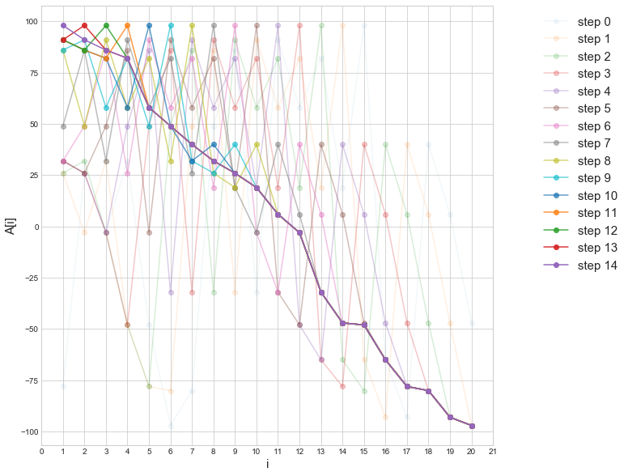

```python
pylab.figure(figsize=(10,10))
for i in range(int(len(AA)/20)):
    pylab.plot(range(20), AA[20*i:20*(i+1)], '-o',
               alpha=20*(i+0.8)/len(AA), label='step {}'.format(i))

pylab.xlabel('i', fontsize=15)
pylab.ylabel('A[i]', fontsize=15)
pylab.xticks(range(-1, len(A)+1), range(len(A)+2));
pylab.legend(fontsize=15, shadow=True, bbox_to_anchor=(1.3,1.0));
```

### 4. Таблица данных

| Класс | Имя | Описание (смысл, диапазон, точность) | Тип | Структура | Формат в/в |
| --- | --- | --- | --- | --- | --- |
| входные данные | fin | название текстового файла с элементами массива А | символ | строка | "+XX.txt" |
| входные данные | fout | название текстового файла с элементами массива А | символ | строка | "+XX.txt" |
| входные данные | method | название метода сортировки массива А | символ | строка | "+XX" |
| входные данные | A | вводимые из текстового файла числа исходного массива | цел | одномерный массив | +XX (:4) |
| выходные данные | A | выводимые в текстовый файл числа сортированного массива | цел | одномерный массив | +XX (:4) |
| промежуточные данные | n | количество элементов массива | цел | простая переменная | --- |
| промежуточные данные | MIN | минимальный элемент при сортировке | цел | простая переменная | --- |
| промежуточные данные | m | индекс минимального элемент при сортировке | цел | простая переменная | --- |
| промежуточные данные | i | индекс текущего элемента, 1≤i≤50 | цел | простая переменная | --- |
| промежуточные данные | j | индекс текущего элемента, 1≤j≤50 | цел | простая переменная | --- |
| промежуточные данные | c | подсчет количества перестановок элементов, 0≤c≤49 | цел | простая переменная | --- |

*! в Delphi выход из цикла с 1 до 20 с шагом +1 происходит при значении 21, из цикла с 20 до 1 – при 0*

### 5. Входная форма

- обр 1.1 Текстовый файл с элементами массива A: $<fin>$
- обр 1.2 Текстовый файл с элементами массива A и элементами сортированного массива A: $<fout>$
- обр 2 Выберете метод сортировки массива A (simple или bubble): $<method>$
- обр 3.1 Сортировка массива A:
- обр 3.2 $ < A[1] > < A[2] > … < A[n] > $

### 6. Выходная форма

- обр 4 Лаб. 7
- обр 5.1 Текстовый файл с элементами массива A: $<fin>$
- обр 5.2 Текстовый файл с элементами массива A и элементами сортированного массива A: $<fout>$
- обр 6 Выберете метод сортировки массива A (simple или bubble): $<method>$
- обр 7.1 Сортировка массива A:
- обр 7.2 $ < A[1] > < A[2] > … < A[n] > \\ ... \\ < A[1] > < A[2] > … < A[n] > $

### 7. Аномалии

-

### 8. Функциональные тесты

| Исходные данные | - | - | - | Результаты | Тест |
| --- | --- | --- | --- | --- | --- |
| fin | fout | method | A | A | № |
| A_Lab7_1.txt | As_Lab7_1.txt | `bubble` | `[-78 26 -3 32 -48 -97 -80 49 86 -32 91 58 82 19 98 -65 -93 40 6 -47]` | `[98 91 86 82 58 49 40 32 26 19 6 -3 -32 -47 -48 -65 -78 -80 -93 -97]` | 1 |
| - | - | - | - | - | - |
| A_Lab7_2.txt | As_Lab7_2.txt | `simple` | `[1 1 0 0 0 0 0 1 1 1 1 1 1 0 0 1 0 0 1 0]` | `[1 1 1 1 1 1 1 1 1 1 0 0 0 0 0 0 0 0 0 0]` | 2 |
| - | - | - | - | - | - |
| A_Lab7_3.txt | As_Lab7_3.txt | `bubble` | `[1 6 7 9 5]` | `[9 7 6 5 1]` | 3 |
| - | - | - | - | - | - |
| A_Lab7_4.txt | As_Lab7_4.txt | `simple` | `[-75 -75 -11 -15 -7 -79 -86 -37 -65 -32]` | `[-7 -11 -15 -32 -37 -65 -75 -75 -79 -86]` | 4 |
| - | - | - | - | - | - |
| A_Lab7_5.txt | As_Lab7_5.txt | `bubble` | `[178 388 727 186 412 87 324 852 190 652]` | `[852 727 652 412 388 324 190 186 178 87]` | 5 |

| № теста | Входные данные | - | - | - | Ожидаемый результат | Смысл теста |
| --- | --- | --- | --- | --- | --- | --- |
| - | - | - | - | - | - | - |
| 1 | fin = 'A_Lab7_1.txt' | fout = 'As_Lab7_1.txt' | method = 'bubble' | A = `[-78 26 -3 32 -48 -97 -80 49 86 -32 91 58 82 19 98 -65 -93 40 6 -47]` | A = `[98 91 86 82 58 49 40 32 26 19 6 -3 -32 -47 -48 -65 -78 -80 -93 -97]` | Подтвердить правильность расчетов для широкого спектра целочисленных значений |
| - | - | - | - | - | - | - |
| 2 | fin = 'A_Lab7_2.txt' | fout = 'As_Lab7_2.txt' | method = 'simple' | A = `[1 1 0 0 0 0 0 1 1 1 1 1 1 0 0 1 0 0 1 0]` | A = `[1 1 1 1 1 1 1 1 1 1 0 0 0 0 0 0 0 0 0 0]` | Протестировать простейший случай с бинарными значениями |
| - | - | - | - | - | - | - |
| 3 | fin = 'A_Lab7_3.txt' | fout = 'As_Lab7_3.txt' | method = 'bubble' | A = `[1 6 7 9 5]` | A = `[9 7 6 5 1]` | Протестировать случай сортировки натуральных чисел |
| - | - | - | - | - | - | - |
| 4 | fin = 'A_Lab7_4.txt' | fout = 'As_Lab7_4.txt' | method = 'simple' | A = `[-75 -75 -11 -15 -7 -79 -86 -37 -65 -32]` | A = `[-7 -11 -15 -32 -37 -65 -75 -75 -79 -86]` | Подтвердить правильность расчетов в случае отрицательных чисел |
| - | - | - | - | - | - | - |
| 5 | fin = 'A_Lab7_5.txt' | fout = 'As_Lab7_5.txt' | method = 'bubble' | A = `[178 388 727 186 412 87 324 852 190 652]` | A = `[852 727 652 412 388 324 190 186 178 87]` | Протестировать массив, состоящий из неотрицательных чисел |

| Метод | - | Результаты | № теста |
| --- | --- | --- | --- |
| - | - | - | - |
| bubble | A | 14 этапов сортировки, корректный результат | 1 |
| - | - | - | - |
| simple | A | 19 этапов сортировки, корректный результат | 2 |
| - | - | - | - |
| bubble | A | 3 этапа сортировки, корректный результат | 3 |
| - | - | - | - |
| simple | A | 9 этапов сортировки, корректный результат | 4 |
| - | - | - | - |
| bubble | A | 7 этапов сортировки, корректный результат | 5 |

### 9. Метод

Отделим ввод-вывод от обработки данных и разделим задачу на три подзадачи:

1. *Подзадача А 0.1.* Запросить названия текстовых файлов ввода-вывода, считать из текстового файла ввода исходные данные (обр.1-3), затем вывести их на экран (обр.4-7.1) для визуального подтверждения.
2. *Подзадача А 0.2.* Решение поставленной задачи: на основе введенных исходных данных (`A`) сформировать сортированный одним из заданных методов (`simple`, `bubble`) массив (`A`)
3. *Подзадача А 0.3.* Ввести полученные результаты (`A`) на экран (обр.7.2) и записать в файл вывода исходный массив и полученный результат.

Ввод-вывод тривиален и представляет собой чисто техническую задачу.

Для осуществления процесса ввода-вывода и обработки массива потребуются промежуточные переменные:

- `i` – индекс текущего элемента массива,
- `j` – индекс текущего элемента массива,
- `n` - количество элементов в массиве,
- `m` - индекс минимального элемент при сортировке,
- `MIN` - минимальный элемент при сортировке,
- `c` - подсчет количества перестановок элементов.

Их следует добавить в таблицу данных.

Алгоритм необходим только для обработка входных данных и расчета результата.

### 10. Алгоритм

[Sample diagrams](http://blockdiag.com/en/blockdiag/examples.html#sample-diagrams)

```python
%%file block_diagram

blockdiag {
    orientation = portrait;
    class start_end [shape = ellipse, fontsize = 15, color = lightskyblue];
    class input_out [shape = flowchart.input, fontsize = 15, width = 600, color = lightcyan];
    class main_box [shape = box, width = 320, height = 150, fontsize = 18];

    Начало ->
    "Вывод заголовка по обр.4 на экран" ->
    "Ввод имени файла по обр.1.1" -> "Ввод имени файла по обр.1.2" ->
    "Ввод названия метода по обр.2" ->
    "Вывод пояснения по обр.3.1" -> "Ввод А из файла по обр.3.2" ->
    "Вывод имени файла по обр.5.1 на экран" -> "Вывод имени файла по обр.5.2 на экран" ->
    "Вывод названия метода по обр.6" ->
    "Вывод пояснения по обр.7.1 на экран" -> "Сортировка массива выбранным методом" ->
    "Вывод А на экран и в файл по обр.7.2" ->
    Конец;

    Начало, Конец [class = "start_end"];
    "Ввод имени файла по обр.1.1", "Ввод имени файла по обр.1.2" [class = "input_out"];
    "Ввод названия метода по обр.2", "Вывод названия метода по обр.6" [class = "input_out"];
    "Вывод пояснения по обр.3.1", "Ввод А из файла по обр.3.2" [class = "input_out"];
    "Вывод имени файла по обр.5.1 на экран", "Вывод имени файла по обр.5.2 на экран" [class = "input_out"];
    "Вывод пояснения по обр.7.1 на экран", "Вывод А на экран и в файл по обр.7.2" [class = "input_out"];
    "Вывод заголовка по обр.4 на экран" [class = "input_out"];
    "Сортировка массива выбранным методом" [class = "main_box"];

    "Вывод пояснения по обр.7.1 на экран" ->
    "Сортировка массива выбранным методом" [label = 'Вх. А', fontsize = 18];
    "Сортировка массива выбранным методом" ->
    "Вывод А на экран и в файл по обр.7.2" [label = 'Вых. A', fontsize = 18];
}
```

```
Overwriting block_diagram
```

```python
!blockdiag block_diagram
```

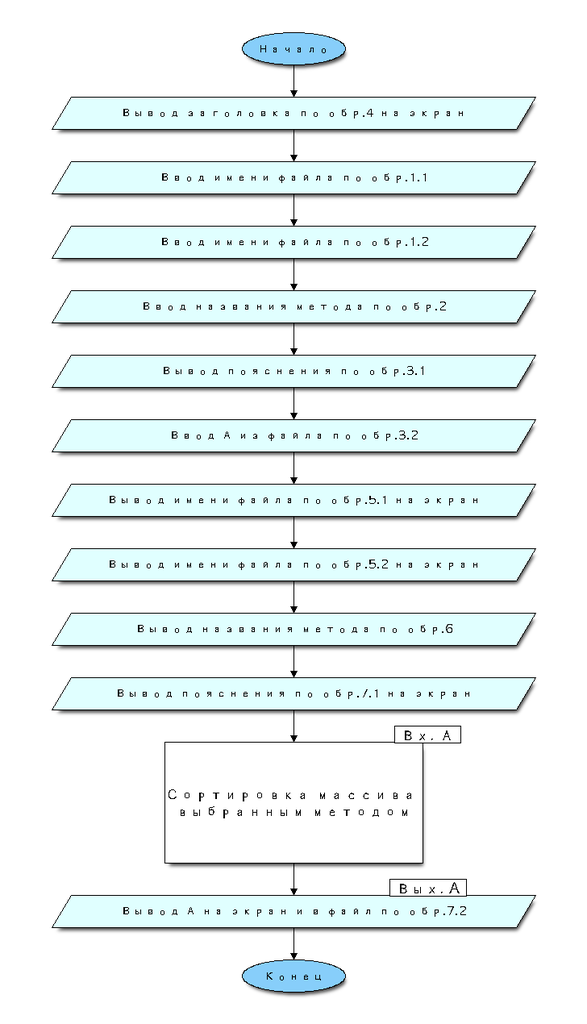

```python
Image("block_diagram.png")
```

### 11. Программа на *Delphi*.

**Диалоговый вариант {ввод названий файлов и данных из текстового файла, вывод на экран и в текстовый файл}**

Синтаксис:

[Pascal Tutorial](https://www.tutorialspoint.com/pascal/index.htm)

```python
program Lab7; //сохранить как lab7.dpr (DPR – Delphi PRoject)
{$APPTYPE CONSOLE}
Uses Windows; // для русификации (сделать комментарием в онлайн-компиляторе!)
    const
        {заглушка для теста 1}
        TA1: array[1..20] of integer = (98,91,86,82,58,49,40,32,26,19,6,-3,-32,-47,-48,-65,-78,-80,-93,-97);
        {заглушка для теста 2}
        TA2: array[1..20] of integer = (1,1,1,1,1,1,1,1,1,1,0,0,0,0,0,0,0,0,0,0);
        {заглушка для теста 3}
        TA3: array[1..5] of integer = (9,7,6,5,1);
        {заглушка для теста 4}
        TA4: array[1..10] of integer = (-7,-11,-15,-32,-37,-65,-75,-75,-79,-86);
        {заглушка для теста 5}
        TA5: array[1..10] of integer = (852,727,652,412,388,324,190,186,178,87);

    var
        i: integer;
        fin, fout, method: string;
        tfin, tfout: TextFile;
        A: array of integer;

    begin
        setConsoleCP(1251); // для ввода  русификация и (сделать строку комментарием в онлайн-компиляторе!)
        setConsoleOutputCP(1251); // для вывода (сделать строку комментарием в онлайн-компиляторе!)

        {A0.1, A0.3 - ввод-вывод входных данных}
        writeln('Лаб.7' :40); {вывод заголовка c переходом на следующую строку по обр.4}

        {ввод-вывод строковой переменной - имени файла с входными данными по обр.1.1, 5.1}
        writeln('Текстовый файл с элементами массива A:  ');
        readln(fin);
        writeln(fin);

        {ввод-вывод строковой переменной - имени файла с выходными данными по обр.1.2, 5.2}
        writeln('Текстовый файл с элементами массива A и элементами сортированного массива A: ');
        readln(fout);
        writeln(fout);

        {ввод-вывод строковой переменной - названия метода сортироки по обр.2, 6}
        writeln('Выберете метод сортировки массива A (simple или bubble): ');
        readln(method);
        writeln(method);

        {ввод-вывод исходного массивa A по обр.3.1, 3.2, 7.1, 7.2}
        writeln('Сортировка массива A: '); {вывод пояснения с переходом на следующую строку}

        AssignFile(tfin, fin); reset(tfin); {открыть файл для чтения}
        AssignFile(tfout, fout); rewrite(tfout); {открыть файл для записи}

        i := 1;

        while not eof(tfin) do
        begin
            SetLength(A,i);
            readln(tfin, A[i]); {ввод элемента и переход на следующую строку}
            writeln(A[i]:4); {вывод элемента и переход на следующую строку на экране}
            writeln(tfout, A[i]:4); {вывод элемента и переход на следующую строку в файле}
            i := i + 1;
        end;

        CloseFile(tfin); {закрыть файл для чтения}

        for i:=1 to 80 do
            write('='); {отделим визуально чертой и строкой введенные и выводимые значения}
        writeln;

        for i:=1 to Length(TA1) do
        begin
            writeln(TA1[i]:4); {вывод элемента и переход на следующую строку на экране}
            writeln(tfout, TA1[i]:4); {вывод элемента и переход на следующую строку в файле}
        end;

        CloseFile(tfout); {закрыть файл для записи}

    end.
```

#### Вариант программы для онлайн-компилятора.

[Compile and Execute Pascal Online](http://www.compileonline.com/compile_pascal_online.php)

```python
// main.pas
program Lab7; // сохранить как lab7.dpr (DPR – Delphi PRoject)
const
    {заглушка для теста 1}
    TA1: array[1..20] of integer = (98,91,86,82,58,49,40,32,26,19,6,-3,-32,-47,-48,-65,-78,-80,-93,-97);

var
    i: integer;
    A: array of integer;
    method: string;

begin

        {A0.1, A0.3 - ввод-вывод входных данных}
        writeln('Лаб.7' :40); {вывод заголовка c переходом на следующую строку по обр.4}

        {ввод-вывод строковой переменной - названия метода сортироки по обр.2, 6}
        writeln('Выберете метод сортировки массива A (simple или bubble): ');
        readln(method);
        writeln(method);

        {ввод-вывод исходного массивa A по обр.3.1, 3.2, 7.1, 7.2}
        writeln('Сортировка массива A: '); {вывод пояснения с переходом на следующую строку}

        i := 2;

        while not eoln do
        begin
            SetLength(A,i);
            readln(A[i]); {ввод элемента и переход на следующую строку}
            writeln(A[i]:4); {вывод элемента и переход на следующую строку на экране}
            i := i + 1;
        end;

        for i:=1 to 80 do
            write('='); {отделим визуально чертой и строкой введенные и выводимые значения}
        writeln;

        for i:=1 to Length(TA1) do
        begin
            writeln(TA1[i]:4); {вывод элемента и переход на следующую строку на экране}
        end;
end.
```

```python
// STDIN
bubble
-78
26
-3
32
-48
-97
-80
49
86
-32
91
58
82
19
98
-65
-93
40
6
-47
```

## Раскрытие абстракции А0.2

*Поскольку условие всей задачи совпадает (за исключением необходимости ввода-вывода) с условием выделенной подзадачи,*

*вместо полной спецификации с пунктами 1-11 выполнено просто дополнение к пунктам 9-11.*

### 9. Метод

Пусть

- $i$ – номер текущий точки,
- $j$ – номер текущий точки,
- $n$ - количество элементов в массиве,
- $m$ - индекс минимального элемент при сортировке,
- $MIN$ - минимальный элемент при сортировке,
- $c$ - переменная для подсчета количества перестановок элементов,
- $A[i] \lor A[j]$ – соответствующий элемент исходного массива A,
- $method$ - название метода сортировки массива А.

При выполнении программы выбирается метод сортировки массива.

Элементы сортируются в цикле, результат каждого этапа выводится на экран.

При сортировке методом *простого выбора*:

на каждом i-ом этапе сортировки меняются местами

- минимальный элемент массива $\{A_1, A_2, …, A_{n - i + 1}\}$ с индексом $m$ и
- элемент с индексом $(n - i + 1)$.

При сортировке методом *"пузырька"*:

- на очередном этапе сравниваются все пары соседних элементов,
- в каждой паре элементы меняются местами, если первый элемент меньше второго,
- последний элемент полученного массива исключается из анализа на следующем этапе.

### 10. Алгоритм

#### Метод простого выбора

```python
%%file block_diagram2

blockdiag {
    orientation = portrait;

    class yes [thick, label = "Да", color = blue, textcolor = blue];
    class no [thick, label = "Нет", color = red, textcolor = red];
    class start_end [shape = ellipse, fontsize = 18, color = lightskyblue];
    class input_out [shape = flowchart.input, fontsize = 18,
                     width = 400, color = lightcyan];
    class loop_in [shape = flowchart.loopin, fontsize = 18,
                   width = 200, color = lightsteelblue];
    class loop_out [shape = flowchart.loopout, fontsize = 18,
                    width = 200, color = lightsteelblue];
    class condition [shape = flowchart.condition, fontsize = 18,
                     width = 250, height = 100, color = lightsteelblue];
    class command_box [shape = roundedbox, fontsize = 18, width = 300];

    Начало -> "j := 0; +1; n-1" -> "MIN := 10000" ->
    "i := 1; +1; n-j" -> "A[i] < MIN" -> "MIN := A[i]; m := i" ->
    "i = n-j" -> "A[m] := A[n-j]; A[n-j] := MIN" ->
    "j = n-1" -> Конец;
    "A[i] < MIN" -> "i = n-j";

    Начало, Конец [class = "start_end"];
    "j := 0; +1; n-1", "i := 1; +1; n-j" [class = "loop_in"];
    "i = n-j", "j = n-1" [class = "loop_out"];
    "A[i] < MIN" [class = "condition"];
    "MIN := 10000", "MIN := A[i]; m := i" [class = "command_box"];
    "A[m] := A[n-j]; A[n-j] := MIN" [class = "command_box"];

    "A[i] < MIN" -> "MIN := A[i]; m := i"  [class = 'yes'];
    "A[i] < MIN" -> "i = n-j" [class = 'no'];
}
```

```
Overwriting block_diagram2
```

```python
!blockdiag block_diagram2
```

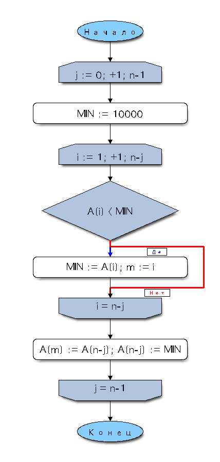

```python
Image("block_diagram2.png")
```

#### Метод "пузырька"

```python
%%file block_diagram2

blockdiag {
    orientation = portrait;

    class yes [thick, label = "Да", color = blue, textcolor = blue];
    class no [thick, label = "Нет", color = red, textcolor = red];
    class start_end [shape = ellipse, fontsize = 18, color = lightskyblue];
    class input_out [shape = flowchart.input, fontsize = 18,
                     width = 400, color = lightcyan];
    class loop_in [shape = flowchart.loopin, fontsize = 18,
                   width = 200, color = lightsteelblue];
    class loop_out [shape = flowchart.loopout, fontsize = 18,
                    width = 200, color = lightsteelblue];
    class condition [shape = flowchart.condition, fontsize = 18,
                     width = 250, height = 100, color = lightsteelblue];
    class command_box [shape = roundedbox, fontsize = 18, width = 300];

    Начало -> "j := 0; +1; n-1" -> "c := 0" ->
    "i := 2; +1; n-j" -> "A[i-1] < A[i]" ->
    "MIN := A[i-1]; A[i-1] := A[i]" -> "A[i] := MIN; c := c + 1" ->
    "i = n-j" -> "c = 0" ->
    "j = n-1" -> Конец;
    "A[i-1] < A[i]" -> "i = n-j";
    "c = 0" -> Конец;

    Начало, Конец [class = "start_end"];
    "j := 0; +1; n-1", "i := 2; +1; n-j" [class = "loop_in"];
    "i = n-j", "j = n-1" [class = "loop_out"];
    "A[i-1] < A[i]", "c = 0" [class = "condition"];
    "c := 0", "MIN := A[i-1]; A[i-1] := A[i]" [class = "command_box"];
    "A[i] := MIN; c := c + 1" [class = "command_box"];

    "A[i-1] < A[i]" -> "MIN := A[i-1]; A[i-1] := A[i]"  [class = 'yes'];
    "A[i-1] < A[i]" -> "i = n-j" [class = 'no'];
    "c = 0" -> Конец  [class = 'yes'];
    "c = 0" -> "j = n-1" [class = 'no'];
}
```

```
Overwriting block_diagram2
```

```python
!blockdiag block_diagram2
```

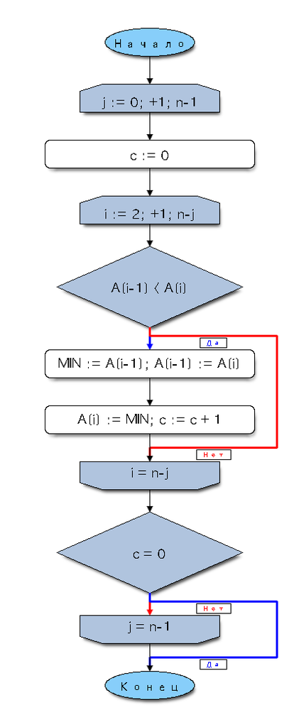

```python
Image("block_diagram2.png")
```

### 11. Программа на *Delphi*.

#### Программный код раскрытия абстракции.

```python
    if method = 'simple' then
    begin
        for j := 0 to n-1 do
        begin
            MIN := 10000;
            for i := 1 to n-j do
            begin
                write(A[i]:4); {вывод элемента на экране}
                if A[i] < MIN then
                begin
                    MIN := A[i];
                    m := i;
                end;
            end;
            A[m] := A[n-j]; A[n-j] := MIN;
            writeln;
        end;
    end;

    if method = 'bubble' then
    begin
        for j := 0 to n-1 do
        begin
        c := 0;
        write(A[1]:4);
            for i := 2 to n-j do
            begin
                write(A[i]:4); {вывод элемента на экране}
                if A[i-1] < A[i] then
                begin
                    MIN := A[i-1];
                    A[i-1] := A[i];
                    A[i] := MIN;
                    c := c + 1;
                end;
            end;
            writeln;
            if c = 0 then break;
        end;
    end;
```

**Диалоговый вариант {ввод названий файлов и данных из текстового файла, вывод на экран и в текстовый файл}**

Синтаксис:

[Pascal Tutorial](https://www.tutorialspoint.com/pascal/index.htm)

```python
program Lab7; // сохранить как lab7.dpr (DPR – Delphi PRoject)
{$APPTYPE CONSOLE}
Uses Windows; // для русификации

const
    A: array [1..30] of integer = (1,2,3,4,5,6,7,8,9,10,
    11,12,13,14,15,16,17,18,19,20,21,22,23,24,25,26,27,28,29,30);
var
    i, j, n, m, c, MIN: integer;
    method: string;
    fin, fout: string;
    tfin, tfout: TextFile;

begin
    setConsoleCP(1251); // для ввода  русификация и
    setConsoleOutputCP(1251); // для вывода

    {A0.1, A0.3 - ввод-вывод входных данных}
    writeln('Лаб.7' :40); {вывод заголовка c переходом на следующую строку по обр.4}

    {ввод-вывод строковой переменной - имени файла с входными данными по обр.1.1, 5.1}
    writeln('Текстовый файл с элементами массива A:  ');
    readln(fin); writeln(fin);

    {ввод-вывод строковой переменной - имени файла с выходными данными по обр.1.2, 5.2}
    writeln('Текстовый файл с элементами массива A и элементами сортированного массива A: ');
    readln(fout); writeln(fout);

    {ввод-вывод строковой переменной - названия метода сортироки по обр.2, 6}
    writeln('Выберете метод сортировки массива A (simple или bubble): ');
    readln(method); writeln(method);

    AssignFile(tfin, fin); reset(tfin); {открыть файл для чтения}
    AssignFile(tfout, fout); rewrite(tfout); {открыть файл для записи}

    {ввод-вывод исходного массивa A по обр.3.1, 3.2, 7.1, 7.2}
    writeln('Сортировка массива A: '); {вывод пояснения с переходом на следующую строку}

    i := 1;
    while not eof(tfin) do
    begin
        readln(tfin, A[i]); {ввод элемента и переход на следующую строку}
        writeln(tfout, A[i]:4);
        {вывод элемента исходного массива и переход на следующую строку в файле}
        i := i + 1;
    end;
    n := i - 1;

    CloseFile(tfin); {закрыть файл для чтения}

    if method = 'simple' then
    begin
        for j := 0 to n-1 do
        begin
            MIN := 10000;
            for i := 1 to n-j do
            begin
                write(A[i]:4); {вывод элемента на экране}
                if A[i] < MIN then
                begin
                    MIN := A[i];
                    m := i;
                end;
            end;
            A[m] := A[n-j]; A[n-j] := MIN;
            writeln;
        end;
    end;

    if method = 'bubble' then
    begin
        for j := 0 to n-1 do
        begin
        c := 0;
        write(A[1]:4);
            for i := 2 to n-j do
            begin
                write(A[i]:4); {вывод элемента на экране}
                if A[i-1] < A[i] then
                begin
                    MIN := A[i-1];
                    A[i-1] := A[i];
                    A[i] := MIN;
                    c := c + 1;
                end;
            end;
            writeln;
            if c = 0 then break;
        end;
    end;

    {отделим визуально чертой и строкой результат сортировки}
    for i:=1 to 80 do write('=');
    writeln;
    for i := 1 to n do
    begin
        write(A[i]:4); {вывод элемента сортированного массива на экране}
        writeln(tfout, A[i]:4);
        {вывод элемента сортированного массива и переход на следующую строку в файле}
    end;

    CloseFile(tfout); {закрыть файл для записи}
end.
```

#### Вариант программы с именами файлов, заданными в качестве параметров.

```python
program Lab7; // сохранить как lab7.dpr (DPR – Delphi PRoject)
{$APPTYPE CONSOLE}
Uses Windows; // для русификации

const
    A: array [1..30] of integer = (1,2,3,4,5,6,7,8,9,10,
    11,12,13,14,15,16,17,18,19,20,21,22,23,24,25,26,27,28,29,30);
var
    i, j, n, m, c, MIN: integer;
    method: string;
    tfin, tfout: TextFile;

begin
    setConsoleCP(1251); // для ввода  русификация и
    setConsoleOutputCP(1251); // для вывода

    {A0.1, A0.3 - ввод-вывод входных данных}
    writeln('Лаб.7' :40); {вывод заголовка c переходом на следующую строку по обр.4}

    if (ParamCount<2) then
    begin
    writeln('CritError: Не заданы параметры программы’);
    readln: exit;
    end;

    AssignFile(tfin, ParamStr(1)); reset(tfin); {открыть файл для чтения}
    AssignFile(tfout, ParamStr(2)); rewrite(tfout); {открыть файл для записи}

    {ввод-вывод строковой переменной - названия метода сортироки по обр.2, 6}
    writeln('Выберете метод сортировки массива A (simple или bubble): ');
    readln(method); writeln(method);

    {ввод-вывод исходного массивa A по обр.3.1, 3.2, 7.1, 7.2}
    writeln('Сортировка массива A: '); {вывод пояснения с переходом на следующую строку}

    i := 1;
    while not eof(tfin) do
    begin
        readln(tfin, A[i]); {ввод элемента и переход на следующую строку}
        writeln(tfout, A[i]:4);
        {вывод элемента исходного массива и переход на следующую строку в файле}
        i := i + 1;
    end;
    n := i - 1;

    CloseFile(tfin); {закрыть файл для чтения}

    if method = 'simple' then
    begin
        for j := 0 to n-1 do
        begin
            MIN := 10000;
            for i := 1 to n-j do
            begin
                write(A[i]:4); {вывод элемента на экране}
                if A[i] < MIN then
                begin
                    MIN := A[i];
                    m := i;
                end;
            end;
            A[m] := A[n-j]; A[n-j] := MIN;
            writeln;
        end;
    end;

    if method = 'bubble' then
    begin
        for j := 0 to n-1 do
        begin
        c := 0;
        write(A[1]:4);
            for i := 2 to n-j do
            begin
                write(A[i]:4); {вывод элемента на экране}
                if A[i-1] < A[i] then
                begin
                    MIN := A[i-1];
                    A[i-1] := A[i];
                    A[i] := MIN;
                    c := c + 1;
                end;
            end;
            writeln;
            if c = 0 then break;
        end;
    end;

    {отделим визуально чертой и строкой результат сортировки}
    for i:=1 to 80 do write('=');
    writeln;
    for i := 1 to n do
    begin
        write(A[i]:4); {вывод элемента сортированного массива на экране}
        writeln(tfout, A[i]:4);
        {вывод элемента сортированного массива и переход на следующую строку в файле}
    end;

    CloseFile(tfout); {закрыть файл для записи}
end.
```

#### Вариант программы для онлайн-компилятора.

[Compile and Execute Pascal Online](http://www.compileonline.com/compile_pascal_online.php)

```python
// main.pas
program Lab7; // сохранить как lab7.dpr (DPR – Delphi PRoject)

const
    A: array [1..30] of integer = (1,2,3,4,5,6,7,8,9,10,
    11,12,13,14,15,16,17,18,19,20,21,22,23,24,25,26,27,28,29,30);
var
    i, j, n, m, c, MIN: integer;
    method: string;

begin

    {A0.1, A0.3 - ввод-вывод входных данных}
    writeln('Лаб.7' :40); {вывод заголовка c переходом на следующую строку по обр.4}

    {ввод-вывод строковой переменной - названия метода сортироки по обр.2, 6}
    writeln('Выберете метод сортировки массива A (simple или bubble): ');
    readln(method);
    writeln(method);

    {ввод-вывод исходного массивa A по обр.3.1, 3.2, 7.1, 7.2}
    writeln('Сортировка массива A: '); {вывод пояснения с переходом на следующую строку}

    i := 2;
    while not eoln do
    begin
        readln(A[i-1]); {ввод элемента и переход на следующую строку}
        i := i + 1;
    end;
    n := i - 2;

    if method = 'simple' then
    begin
        for j := 0 to n-1 do
        begin
            MIN := 10000;
            for i := 1 to n-j do
            begin
                write(A[i]:4); {вывод элемента на экране}
                if A[i] < MIN then
                begin
                    MIN := A[i];
                    m := i;
                end;
            end;
            A[m] := A[n-j]; A[n-j] := MIN;
            writeln;
        end;
    end;

    if method = 'bubble' then
    begin
        for j := 0 to n-1 do
        begin
        c := 0;
        write(A[1]:4);
            for i := 2 to n-j do
            begin
                write(A[i]:4); {вывод элемента на экране}
                if A[i-1] < A[i] then
                begin
                    MIN := A[i-1];
                    A[i-1] := A[i];
                    A[i] := MIN;
                    c := c + 1;
                end;
            end;
            writeln;
            if c = 0 then break;
        end;
    end;

    {отделим визуально чертой и строкой результат сортировки}
    for i:=1 to 80 do write('=');
    writeln;
    for i := 1 to n do write(A[i]:4);

end.
```

```python
// STDIN
simple
-78
26
-3
32
-48
-97
-80
49
86
-32
91
58
82
19
98
-65
-93
40
6
-47
```